# RSV (AREXVY) - Peripheral swelling

OpenSourcePV

Data Lock Point: Data contains VAERS reports processed as of 2023_11_24 (Year_Month_Day). Flag NEW was defined against reports processed as of 2023_10_27.

# 1 Quantitative Signal status

## 1.1 Disproportionality

The vaccine-event combination “RSV (AREXVY) - Peripheral swelling” was **a signal of disproportionate reporting** with an EB05 value of 2.04.

The threshold for being flagged as a signal of disproportionate reporting is an EB05>=2 meaning that there there is a 95% probability that the reporting of Peripheral swelling was at least twice post exposure to RSV (AREXVY) than post all vaccines. Under the assumption of no causality between RSV (AREXVY) and Peripheral swelling and no bias it would have been expected to observe an EBGM of 1.

It means that the quantified causality criterion of strength of association is **met**.

*It is to be noted that the nature of the spontaneous report does not provide reliable estimates of the strength of association (whatever the choice of the disproportionality method) and that some reporting bias or difference in demographic characteristics might explain the (un)observed disproportion*.

## 1.2 Time-to-onset

The vaccine-event combination “RSV (AREXVY) - Peripheral swelling” was **not a signal of unexpected time-to-onset distribution** with a p-value of the two-sample Kolmogorov-Smirnov test being 0.0903706 and distance between the two empirical cumulative distributions being of 15.8179342%.

The threshold for being flagged as a signal of unexpected time-to-onset distribution is a P-value of the two-sample Kolmogorov-Smirnov test <0.001 and a distance between the two empirical distributions larger than 20%. Under the assumption of no causality and no bias, it would have been expected that the time-to-onset distribution for “Peripheral swelling” would have been the same post RSV (AREXVY) than post other vaccines. The two-sample Kolmogorov-Smirnov tests this hypothesis.

It means that the quantified causality criterion of temporality is **not met**.

*It is to be noted that the nature of the spontaneous report does not provide reliable estimates of the temporal relationship between the exposure and the occurrence of the events as there is the reporting bias over time: the latter the event occurs after exposure, the less chance it has to be reported. Other biases could distort the reported time-to-onset distribution (media attention, etc.)*

## 1.3 Overall

Based on the screening of the Empirical Bayes Geometric Mean (EBGM) and the screening of the time-to-onset distribution,the vaccine-event combination “RSV (AREXVY) - Peripheral swelling” is **considered as quantitative signal**.

# 2 Signal History

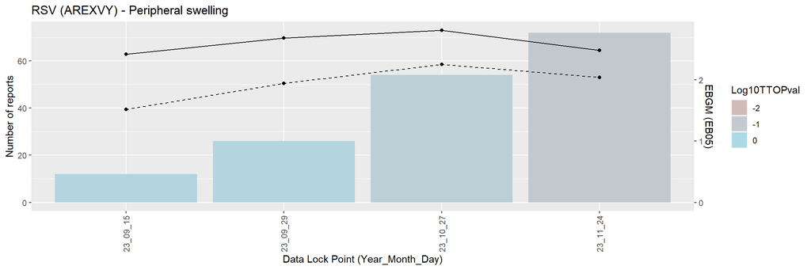

# 3 Case series

## 3.1 Seriousness

A total of 72 reports of Peripheral swelling were received post exposure to RSV (AREXVY). Among them:

- 0 (0.0 %) were fatal cases.
- 0 (0.0 %) were life threatening cases.
- 2 (2.8 %) were hospitalized cases.
- 0 (0.0 %) were emergency room cases.
- 0 (0.0 %) were cases with disabilies.

18 new cases were received since last data refresh.

## 3.2 Demographic characteristics

72 cases of Peripheral swelling post RSV (AREXVY) were reported in VAERS:

- Among them, there were 64 (88.9%) female cases and 7 (9.7%) male cases while the overall female:male ratio is 69:26%.
- The mean (median) age for patients presenting symptoms of Peripheral swelling was 73 (73) years while the overall mean (median) age was 71 (71) years.
- The top 5 contributing US states for patients presenting symptoms of Peripheral swelling were FL ( 16.7 %) , CA ( 9.7 %) , NA ( 6.9 %) , IL ( 5.6 %) , TX ( 5.6 %) while overall the top 5 of contributing US states are NA ( 11.1 %) , FL ( 10.2 %) , CA ( 8.5 %) , NY ( 6.1 %) , TX ( 4.2 %)

# 4 Listing of the cases

Narratives can be made visible clicking on the ⊕ symbol.

|  | VAERS_ID | Sex/Age (Years) | Receipt Date | Seriousness status | List of symptoms | new | SYMPTOM_TEXT |
| --- | --- | --- | --- | --- | --- | --- | --- |
| &oplus; | 2675705 | F/71 | 08/23/2023 |  | Abdominal pain upper, Asthenia, Discomfort, Fatigue, Headache, Pain in extremity, Peripheral swelling, Presyncope | No | She got her vaccines one in one arm and the one in the other The arm became very swollen and very very sore That evening all night she was in bed very uncomfortable In the morning yesterday when she s… |
| &oplus; | 2676870 | F/74 | 08/25/2023 |  | Influenza like illness, Injection site swelling, Peripheral swelling | No | She had swelling in her vaccinated arm She indicated all of her upper arm was swollen significantly for the last 2 days She states that the swelling around the injection site has mostly resolved today… |
| &oplus; | 2676939 | F/81 | 08/26/2023 |  | Erythema, Injection site erythema, Injection site nodule, Injection site swelling, Injection site warmth, Peripheral swelling, Skin warm | No | patient stated that her arm became very warm and turned red with a knot and swelling occuring that started at her injection site and moved down her arm It started two days afer her injections |
| &oplus; | 2677168 | F/64 | 08/28/2023 |  | Joint swelling, Peripheral swelling | No | Patient reported swollen left wrist and hand on 8 27 2023 |
| &oplus; | 2678182 | F/74 | 08/31/2023 |  | Peripheral swelling, Skin warm, Vaccination site erythema, Vaccination site rash | No | Red rash that starts below where the vaccination was given and goes towards my elbow Its on the same line as the vaccine and towards the inside of my arm Looks familiar to the covid rash Arm is slight… |
| &oplus; | 2679688 | F/78 | 09/06/2023 |  | Arthralgia, Disorientation, Dizziness, Erythema, Headache, Injection site pain, Peripheral swelling, Pruritus | No | Redness and swelling on the right arm itching on arm and pain at site of injection Dizziness or disoriented feeling overall Headache persisting since receiving vaccine responds to acetaminophen Achine… |
| &oplus; | 2680470 | F/68 | 09/08/2023 |  | Erythema, Fatigue, Headache, Injection site pain, Nausea, Pain in extremity, Peripheral swelling, Pruritus, Skin warm | No | She got her vaccine it hurt a little bit was burning It was more painful going in than the Heb A B that she got on her left arm and she had no problem with her left arm As the day went on it started t… |
| &oplus; | 2680519 | F/71 | 09/08/2023 |  | Peripheral swelling, Urticaria | No | Patient reported hives and swelling of the hands to the pharmacy on 9 8 23 that began in the morning the day after receiving the vaccine She first used benadryl gel but said that did not help so she t… |
| &oplus; | 2680684 | F/76 | 09/09/2023 |  | Erythema, Fatigue, Injection site erythema, Injection site swelling, Peripheral swelling, Pyrexia | No | Patient had significant swelling and redness in left arm after receiving the Arexvy Said swelled up to lump the size of a golf ball and had redness the size of a tennis ball Felt tired and feverish th… |
| &oplus; | 2680712 | F/79 | 09/10/2023 |  | Peripheral swelling, Urticaria | No | Patient presented to the pharmacy with a severe swollen left arm The arm was more swollen to the inner of the left arm Also presented with the hives on the back of both legs |

[output cut: 62 more lines]

# 5 Disclaimer

This analysis is exploratory only and authors cannot be held responsible for any decision made using these data. It is important to distinguish quantitative signals such as disproportionate reporting, unexpected time-to-onset patterns or cluster from safety signals. Only a qualitative review using multiple data source (literature, clinical trials, etc.) and multiple causality criteria assessment could qualify quantitative signals into safety signals.